# Understanding ECB communication through Topic Modelling and Sentiment Analysis

2024-03-01

# Chapter I. Introduction

European Central Bank communication influences the expectations regarding the future condition of the economy in the European Union and its member states. Hence, understanding the patterns hidden behind the ECB board members’ speeches is a vital issue not only for policymakers and investors but also for the broader public. This project seeks to uncover the primary topics discussed by the ECB, how they change over time and what is their emotional tone.

Other approach would be sentiment analysis, namely polarity classification. Through this approach, we would obtain relative sentiment score that would indicate when the ECB board members were the most positive and the most negative in their speeches. Our study, in this part, is similar to (Warin & Sanger, 2020) and (Anastasiou & Katsafados, 2023), who both used sentiment analysis in researching on ECB members utterances. We will identify words that influence relative sentiment the most and plot sentiment across time. Additionally, we would compare sucha a measure with Polish inflation expectations to suggest a path for future research in the field.

## Libraries and packages

We require various packages for our project to run smoothly and effectively.

[output not shown]

```r
library(tidyverse) # less messy code + lengthening/widening data + much more
library(tidytext) # for sentiment lexicons, tokenization and more
library(topicmodels) # for topic modelling (LDA)
library(tm) # for general text mining purposes
library(SnowballC) # for stemming
library(rminer) # for data mining classifications
library(dplyr) # handling the data easier
library(ggplot2) # plotting
library(ggthemes) # for nicer themes
library(stringr) # strings operations
library(textclean) # to clean and normalize text
library(textmineR) # for general text minig
library(textcat) # for language identification
library(quanteda) # for quantitative text analysis
```

# Chapter II. Dataset

```r
# loading the data
speeches <- read.delim("all_ECB_speeches.csv", sep = "|")
```

Before topic modeling, some data preprocessing was needed. All rows with missing observations were removed, words were converted to lowercase, white spaces were removed and contractions and elongations were replaced. Since the title, subtitle, date, and place of the speech were also included in speeches content, this information was removed from each speech. Some texts were not in English, so the language of the speeches was firstly detected and then non-English speeches (Spanish, Catalan, French, and German) were removed. 1261 observations were left. Some stopwords were dropped (they appeared frequently in each topic and their inclusion in the analysis would be minsinformative).

```r
speeches$contents <- gsub("  SPEECH  ", "", speeches$contents) # removing SPEECH word
speeches <- speeches %>%
  filter(!is.na(contents) & contents != "") # removing empty rows


for (i in 1:nrow(speeches)) {
  speeches$contents[i] <- gsub(speeches$title[i], "", speeches$contents[i])
} # removing the title from the content of the speech


for (i in 1:nrow(speeches)) {
  try(speeches$contents[i] <- gsub(speeches$subtitle[i], "", speeches$contents[i]))
} # removing the subtitle from the content of the speech
```

[output not shown]

```r
speeches$contents <- gsub("\\b\\p{Lu}{1}[a-zA-Z\\s]+(?=,)", "", speeches$contents, perl = TRUE)# removing place of the speech

speeches$contents <- gsub("\\b\\d{1,2}\\s+(January|February|March|April|May|June|July|August|September|October|November|December)\\s+\\d{4}\\b", "", speeches$contents) # removing dates from the contents table

speeches$contents <- str_replace_all(as.character(speeches$contents), '[^a-zA-Z \']',' ')

speeches <- speeches %>%
  mutate_all(str_to_lower) %>%
  mutate_all(replace_contraction) %>%
  mutate_all(replace_word_elongation) %>%
  mutate_all(str_squish) %>%
  mutate_all(str_trim)

speeches_lang <- textcat(speeches$contents,p=textcat::TC_char_profiles,method="CT", options=list()) # language detection
speeches_lang <- as.data.frame(speeches_lang)
speeches_combined <- cbind(speeches, speeches_lang)

speeches <- speeches_combined[speeches_combined$speeches_lang == 'english', ] # removing speeches which are not in English

speeches$contents <- sapply(speeches$contents, function(text) {
  tokens <- tokens(text)
  tokens <- tokens_remove(tokens, stopwords("en"))
  tokens <- tokens_remove(tokens, stopwords("de"))
  tokens <- tokens_remove(tokens, stopwords("es"))
  tokens <- tokens_remove(tokens, c('financial', 'policy', 'euro', 'economic', 'area', 'monetary', 'market', 'markets', 'ecb', 'bank'))
  return(paste(tokens, collapse = " "))
})
```

# Chapter III. Topic Modeling

LDA is a generative probabilistic model, where each document is treated as a mixture of topics occurring in the corpus, and each word is ascribed to a particular topic with some probability. After multiple iterations, the words with the highest probability of appearing in a particular topic can be displayed (source: lecture notes).

```r
top_terms_by_topic_LDA <- function(contents, # should be a columm from a dataframe
                                   plot = T, # return a plot? TRUE by defult
                                   number_of_topics = 6) # number of topics (4 by default)
{
  # create a corpus (type of object expected by tm) and document term matrix
  Corpus <- Corpus(VectorSource(contents)) # make a corpus object
  DTM <- DocumentTermMatrix(Corpus) # get the count of words/document

  # remove any empty rows in our document term matrix (if there are any
  # we'll get an error when we try to run our LDA)
  unique_indexes <- unique(DTM$i) # get the index of each unique value
  DTM <- DTM[unique_indexes,] # get a subset of only those indexes

  # preform LDA & get the words/topic in a tidy text format
  lda <- LDA(DTM, k = number_of_topics, control = list(seed = 1234))
  topics <- tidy(lda, matrix = "beta")

  # get the top ten terms for each topic
  top_terms <- topics  %>% # take the topics data frame and..
    group_by(topic) %>% # treat each topic as a different group
    top_n(10, beta) %>% # get the top 10 most informative words
    ungroup() %>% # ungroup
    arrange(topic, -beta) # arrange words in descending informativeness

  # if the user asks for a plot (TRUE by default)
  if(plot == T){
    # plot the top ten terms for each topic in order
    top_terms %>% # take the top terms
      mutate(term = reorder(term, beta)) %>% # sort terms by beta value
      ggplot(aes(term, beta, fill = factor(topic))) + # plot beta by theme
      geom_col(show.legend = FALSE) + # as a bar plot
      facet_wrap(~ topic, scales = "free") + # which each topic in a separate plot
      labs(x = NULL, y = "Beta") + # no x label, change y label
      coord_flip() # turn bars sideways
  }else{
    # if the user does not request a plot
    # return a list of sorted terms instead
    return(top_terms)
  }
}
```

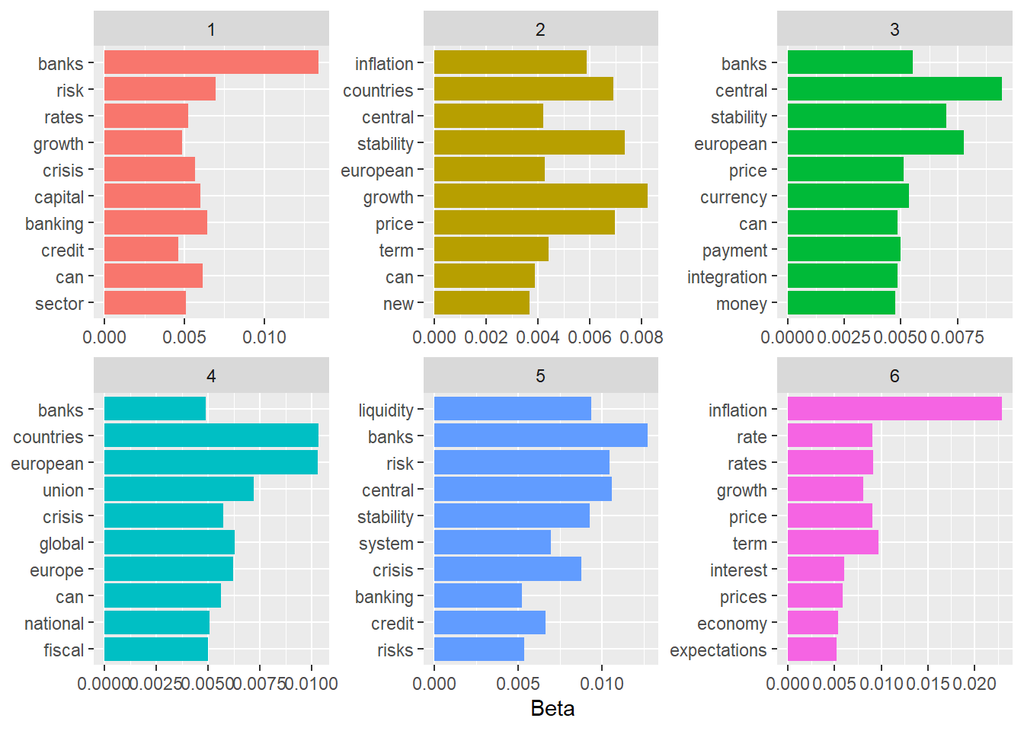

```r
a<-top_terms_by_topic_LDA(contents = speeches$contents, plot = TRUE, number_of_topics = 6)
a
```

Based on the generated top 10 words in each category, the topics emerging in the speeches are:

1. Financial stability
2. Single currency
3. Credits and liquidity
4. Banking system
5. Monetary policy
6. Inflation

```r
speeches$date <- as.Date(speeches$date)

pre_crisis_period <- c(as.Date("1997-01-01"), as.Date("2007-12-31"))
crisis_period <- c(as.Date("2008-01-01"), as.Date("2009-12-31"))
post_crisis_period <- c(as.Date("2010-01-01"), as.Date("2020-03-16"))
covid_period <- c(as.Date("2020-03-17"), as.Date("2023-12-31"))

# dividing speeches by periods
pre_crisis_speeches_df <- filter(speeches, date >= pre_crisis_period[1] & date <= pre_crisis_period[2])
crisis_speeches_df <- filter(speeches, date >= crisis_period[1] & date <= crisis_period[2])
post_crisis_speeches_df <- filter(speeches, date >= post_crisis_period[1] & date <= post_crisis_period[2])
covid_speeches_df <- filter(speeches, date >= covid_period[1] & date <= covid_period[2])
```

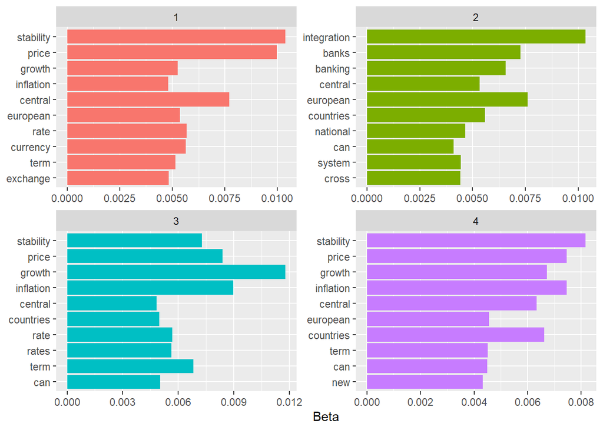

```r
b<-top_terms_by_topic_LDA(contents = pre_crisis_speeches_df$contents, plot = TRUE, number_of_topics = 4)
b
```

Topics before crisis:

1. Exchange rates and price stability
2. Inflation
3. Integration of banking systems
4. Singe currency

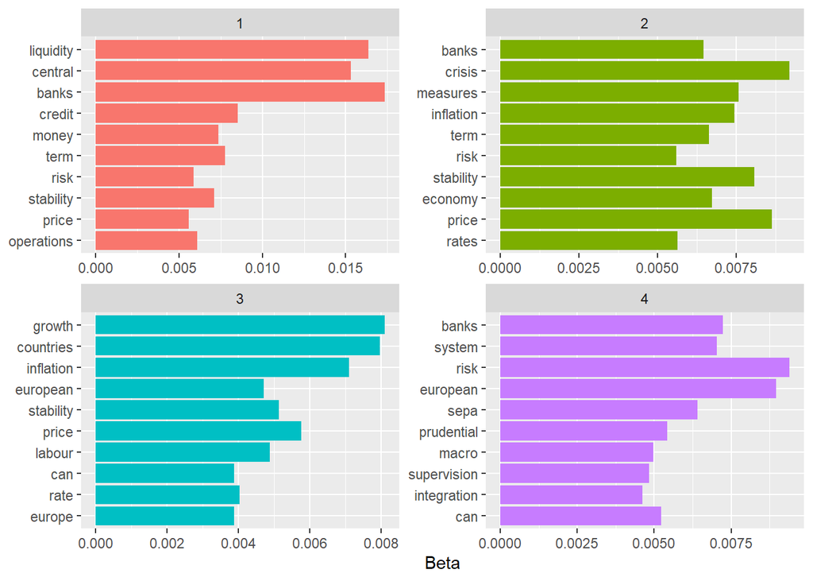

```r
c<-top_terms_by_topic_LDA(contents = crisis_speeches_df$contents, plot = TRUE, number_of_topics = 4)
c
```

Topics during crisis:

1. Inflation
2. SEPA
3. Regulatory framework
4. Liquidity and credits

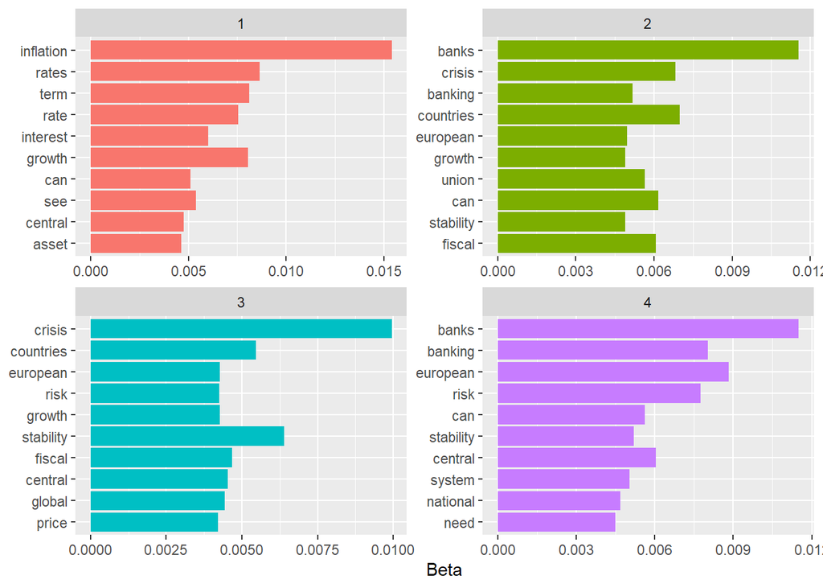

```r
d<-top_terms_by_topic_LDA(contents = post_crisis_speeches_df$contents, plot = TRUE, number_of_topics = 4)
d
```

Topics :

1. Banking
2. Monetary policy
3. Financial crisis
4. Financial crisis

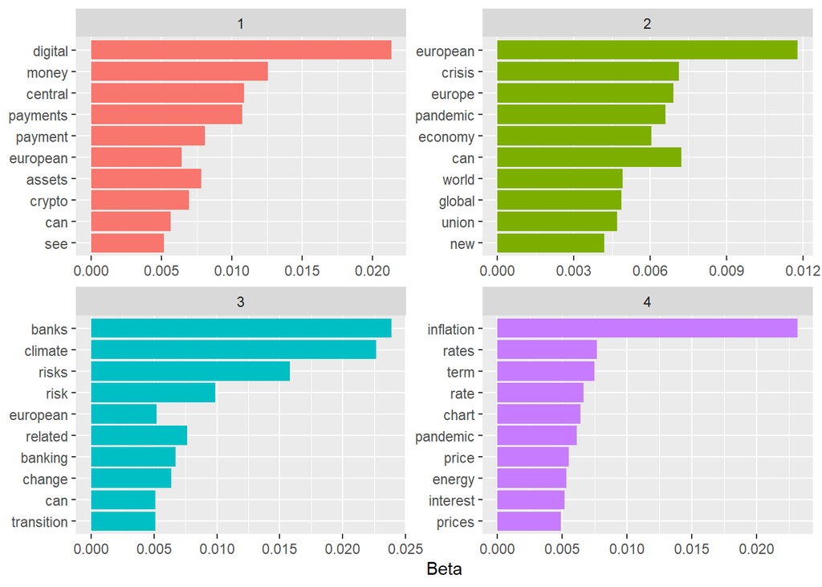

```r
e<-top_terms_by_topic_LDA(contents = covid_speeches_df$contents, plot = TRUE, number_of_topics = 4)
e
```

Topics during (and after) COVID-19 pandemic:

1. Digital payments
2. Climate change
3. Inflation and energy prices
4. Pandemic

# Chapter IV. Sentiment Analysis

We create a new df with a sentiment score calculated by the words used in a speech. The table consist of positive score, negative score, sentiment value and relative sentiment, where -100 means the most negative sentiment and 100 the most positive.

```r
speeches_sentiment<- data.frame(index = 0,
                     date = as.Date("2024-03-01"),
                     speaker = "speaker",
                     negative = 0,
                     positive = 0,
                     sentiment = 0,
                     relative.sentiment = 0)
for (i in 1:nrow(speeches)){
  start <- speeches[i,"contents"]
  dat <- map(start, function(x) {
  tibble(text = unlist(str_split(x, pattern = "\\s"))) %>%
    rowid_to_column(var = "number")
    })
  dat <- as.data.frame(dat[[1]])
  colnames(dat)[2] <- "word" # change of column's name to easily join with dictionaries

  dat_bing <- dat %>%
    inner_join(get_sentiments("bing"), by = join_by(word))

  table<- data.frame(index = i,
                     date = speeches[i, 1],
                     speaker = speeches[i, 2],
                     negative = count(dat_bing, sentiment)[1,2],
                     positive = count(dat_bing, sentiment)[2,2],
                     sentiment = count(dat_bing, sentiment)[2,2] - count(dat_bing, sentiment)[1,2],
                     relative.sentiment = (count(dat_bing, sentiment)[2,2] - count(dat_bing, sentiment)[1,2]) / (count(dat_bing, sentiment)[2,2] + count(dat_bing, sentiment)[1,2])*100)
  speeches_sentiment <- rbind(speeches_sentiment, table)
  }

speeches_sentiment <- speeches_sentiment[-1,] %>%
  drop_na()
rownames(speeches_sentiment) <- NULL

head(speeches_sentiment, 15)
```

```
##    index       date           speaker negative positive sentiment
## 1      1 2024-02-26 christine lagarde       29       53        24
## 2      2 2024-02-16   isabel schnabel      110      198        88
## 3      3 2024-02-15 christine lagarde       14       40        26
## 4      4 2024-02-14   piero cipollone       19       75        56
## 5      5 2024-02-14   luis de guindos       64       64         0
## 6      6 2024-02-12   piero cipollone       72      148        76
## 7      7 2024-02-12    philip r. lane       72      117        45
## 8      8 2024-02-09   piero cipollone       97      152        55
## 9      9 2024-01-17   piero cipollone       73       63       -10
## 10    10 2024-01-10   luis de guindos       37       41         4
## 11    11 2023-12-07    frank elderson      112       93       -19
## 12    12 2023-12-04 christine lagarde       92      130        38
## 13    13 2023-11-30 christine lagarde       42       52        10
## 14    14 2023-11-27 christine lagarde       34       46        12
```

[output cut: 17 more lines]

Then, we will plot relative sentiment using lm function.

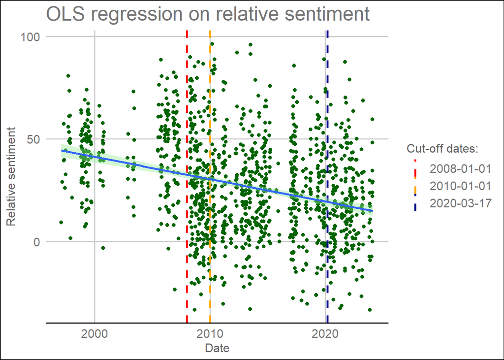

```r
ggplot(speeches_sentiment, aes(x = date, y = relative.sentiment)) +
  geom_point(color = "darkgreen", size= 1.5) +
  geom_vline(aes(xintercept=as.Date("2008-01-01"),
                 color="2008-01-01"), linetype="dashed", size=1)+
  geom_vline(aes(xintercept=as.Date("2010-01-01"),
                 color="2010-01-01"), linetype="dashed", size=1)+
  geom_vline(aes(xintercept=as.Date("2020-03-17"),
                 color="2020-03-17"), linetype="dashed", size=1)+
  scale_color_manual(name = "Cut-off dates:",
                     values = c("2008-01-01" = "red",
                                "2010-01-01" = "orange",
                                "2020-03-17" = "darkblue"))+
  labs(title = 'OLS regression on relative sentiment',
       x = 'Date' ,
       y = 'Relative sentiment')  +
    geom_smooth(method='lm', formula= y~x, fill="lightgreen")+
  ggthemes::theme_gdocs()
```

It is clear that over time the trend is negative. Now we will use loess function and add Polish inflation expectations for the reference (calculated by T. Mętrak in his BA thesis).

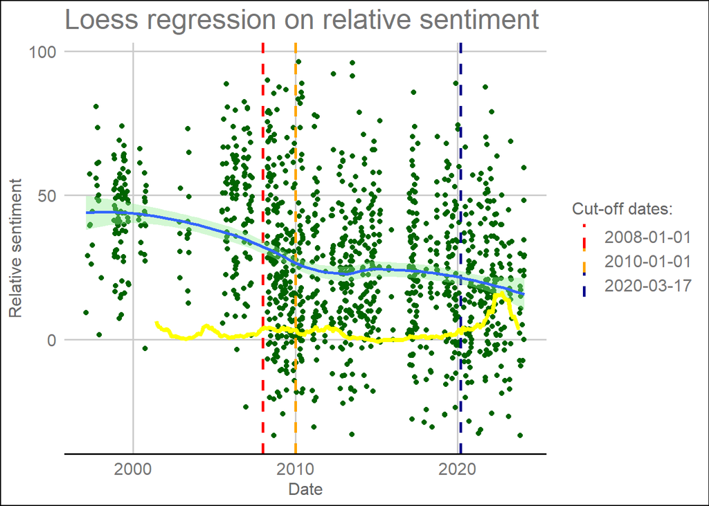

```r
exp <- read.csv("EXP_Poland_01_03_2024.csv")
exp$Expectations.time <- lubridate::ym(exp$Expectations.time)

ggplot(speeches_sentiment, aes(x = date, y = relative.sentiment)) +
  geom_point(color = "darkgreen", size= 1.5) +
  geom_vline(aes(xintercept=as.Date("2008-01-01"),
                 color="2008-01-01"), linetype="dashed", size=1)+
  geom_vline(aes(xintercept=as.Date("2010-01-01"),
                 color="2010-01-01"), linetype="dashed", size=1)+
  geom_vline(aes(xintercept=as.Date("2020-03-17"),
                 color="2020-03-17"), linetype="dashed", size=1)+
  scale_color_manual(name = "Cut-off dates:",
                     values = c("2008-01-01" = "red",
                                "2010-01-01" = "orange",
                                "2020-03-17" = "darkblue"))+
  labs(title = 'Loess regression on relative sentiment',
       x = 'Date' ,
       y = 'Relative sentiment')  +
    geom_smooth(method='loess', formula= y~x, fill="lightgreen")+
    geom_line(exp, mapping=aes(x=Expectations.time, y=expect),
              size=1.5, color="yellow")+
  ggthemes::theme_gdocs()
```